# Predição da satisfação dos passageiros de companhias aéreas

25/06/2022

## Objetivo

O Objetivo deste trabalho é estudar os perfis e respostas de pesquisas de satisfação de passageiros de companhias aéreas para propor modelos que consigam predizer se um passageiro estará satisfeito com um voo.

### Importando Bibliotecas

```r
library(tidyverse)
library(GGally)
library(ggplot2)
library(ggrepel)
library(factoextra)
library(skimr)
library(plotly)
library(cluster)
library(janitor)
library(rsample)
library(yardstick)
library(caret)
library(ggpubr)
library(keras)
library(Matrix)
library(tidymodels)
theme_set(theme_pubr())
```

## Análise Exploratória

Realizou-se uma primeira contagem das variáveis da base de dados e percebeu-se que há um maior número de passageiros fiéis e viagens de negócio. Não há distinção no número de homens e mulheres e a classe Business é a mais utilizada.

```r
bdzero <- read.csv("airline.csv")

bdzero[ ,c('X')] <- list(NULL)


genero <- ggplot(bdzero, aes(Gender), ) + geom_bar() + xlab("Gênero") + ylab("Contagem")

tipo_cliente <- ggplot(bdzero, aes(Customer.Type)) + geom_bar() + xlab("Tipo de Cliente") + ylab("Contagem")

tipo_viagem <- ggplot(bdzero, aes(Type.of.Travel)) + geom_bar() + xlab("Tipo de Viagem") + ylab("Contagem")

classe <- ggplot(bdzero, aes(Class)) + geom_bar() + xlab("Classe") + ylab("Contagem")


figure <- ggarrange(genero, tipo_cliente, tipo_viagem, classe,
                    ncol = 2, nrow = 2)
skim(bdzero)
```

Data summary

| Name | bdzero |
| --- | --- |
| Number of rows | 41561 |
| Number of columns | 24 |
| _______________________ |  |
| Column type frequency: |  |
| character | 5 |
| numeric | 19 |
| ________________________ |  |
| Group variables | None |

**Variable type: character**

| skim_variable | n_missing | complete_rate | min | max | empty | n_unique | whitespace |
| --- | --- | --- | --- | --- | --- | --- | --- |
| Gender | 0 | 1 | 4 | 6 | 0 | 2 | 0 |
| Customer.Type | 0 | 1 | 14 | 17 | 0 | 2 | 0 |
| Type.of.Travel | 0 | 1 | 15 | 15 | 0 | 2 | 0 |
| Class | 0 | 1 | 3 | 8 | 0 | 3 | 0 |
| satisfaction | 0 | 1 | 9 | 23 | 0 | 2 | 0 |

**Variable type: numeric**

| skim_variable | n_missing | complete_rate | mean | sd | p0 | p25 | p50 | p75 | p100 | hist |
| --- | --- | --- | --- | --- | --- | --- | --- | --- | --- | --- |
| id | 0 | 1 | 64939.93 | 37388.29 | 1 | 32713 | 64896 | 97352 | 129879 | ▇▇▇▇▇ |
| Age | 0 | 1 | 39.41 | 15.14 | 7 | 27 | 40 | 51 | 85 | ▃▇▇▅▁ |
| Flight.Distance | 0 | 1 | 1189.12 | 997.15 | 31 | 414 | 843 | 1744 | 4983 | ▇▃▂▁▁ |
| Inflight.wifi.service | 0 | 1 | 2.73 | 1.33 | 0 | 2 | 3 | 4 | 5 | ▆▇▇▆▃ |
| Departure.Arrival.time.convenient | 0 | 1 | 3.05 | 1.52 | 0 | 2 | 3 | 4 | 5 | ▆▆▆▇▇ |
| Ease.of.Online.booking | 0 | 1 | 2.76 | 1.40 | 0 | 2 | 3 | 4 | 5 | ▇▇▇▆▅ |
| Gate.location | 0 | 1 | 2.97 | 1.27 | 1 | 2 | 3 | 4 | 5 | ▅▆▇▇▃ |
| Food.and.drink | 0 | 1 | 3.20 | 1.33 | 0 | 2 | 3 | 4 | 5 | ▅▇▇▇▇ |
| Online.boarding | 0 | 1 | 3.25 | 1.35 | 0 | 2 | 3 | 4 | 5 | ▃▅▆▇▆ |
| Seat.comfort | 0 | 1 | 3.44 | 1.32 | 1 | 2 | 4 | 5 | 5 | ▃▃▅▇▇ |
| Inflight.entertainment | 0 | 1 | 3.36 | 1.33 | 0 | 2 | 4 | 4 | 5 | ▃▅▅▇▇ |
| On.board.service | 0 | 1 | 3.38 | 1.29 | 1 | 2 | 4 | 4 | 5 | ▃▃▆▇▆ |
| Leg.room.service | 0 | 1 | 3.35 | 1.31 | 0 | 2 | 4 | 4 | 5 | ▃▆▆▇▇ |
| Baggage.handling | 0 | 1 | 3.63 | 1.18 | 1 | 3 | 4 | 5 | 5 | ▂▂▅▇▆ |
| Checkin.service | 0 | 1 | 3.31 | 1.27 | 1 | 3 | 3 | 4 | 5 | ▃▃▇▇▆ |
| Inflight.service | 0 | 1 | 3.64 | 1.17 | 1 | 3 | 4 | 5 | 5 | ▂▂▅▇▆ |
| Cleanliness | 0 | 1 | 3.29 | 1.31 | 0 | 2 | 3 | 4 | 5 | ▃▅▇▇▇ |
| Departure.Delay.in.Minutes | 0 | 1 | 14.68 | 37.67 | 0 | 0 | 0 | 12 | 1592 | ▇▁▁▁▁ |
| Arrival.Delay.in.Minutes | 126 | 1 | 15.06 | 38.29 | 0 | 0 | 0 | 13 | 1584 | ▇▁▁▁▁ |

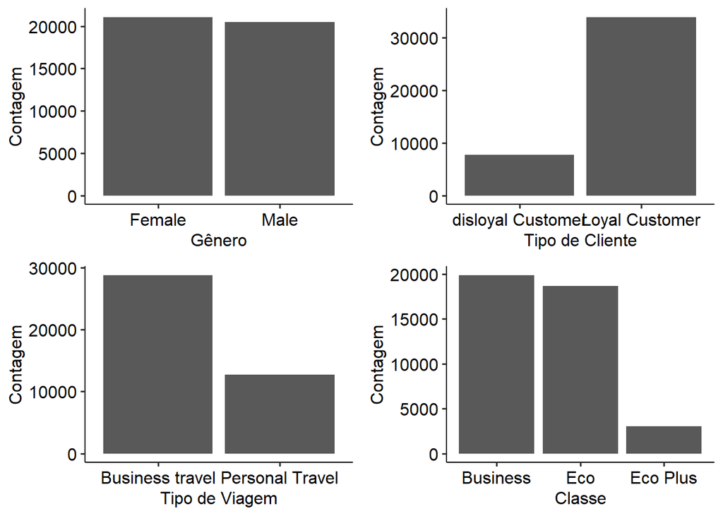

```r
figure
```

### Construção do PCA

Para entender melhor quais fatores influenciam na satisfação do passageiro, foi feito um PCA (Principal Component Analysis): técnica para reduzir as dimensões de um conjunto de variáveis através da criação de novas variáveis não correlacionadas que objetivam abarcar a maior variância da amostra. Retirou-se, então, algumas colunas que não serão utilizadas no PCA.

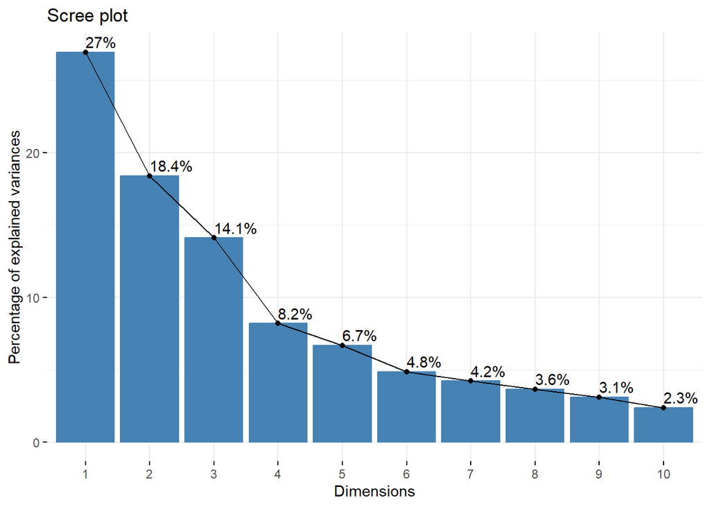

```r
bd1 <- read.csv("airline.csv")


bd1[ ,c('X', 'Customer.Type','Gender','id','Age','Type.of.Travel',
        'Class','Flight.Distance','satisfaction',"Departure.Delay.in.Minutes",
        "Arrival.Delay.in.Minutes")] <- list(NULL)

bd1[is.na(bd1)] <- 0

set.seed(1234)
X <- bd1
pca <- prcomp(X)
pca$rotation <- -pca$rotation
pca$x <- -pca$x
Phi <- pca$rotation
Z <- pca$x
fviz_eig(pca, addlabels = TRUE)
```

Percebe-se que três dimensões explicam carca de 60% dos dados, logo foi realizada a diminuição das dimensões do dataframe inicial para somente três dimensões (drivers) e cada uma foi nomeada a partir da análise das contribuições das questões para cada driver.

#### 1º Driver: CONFORTO

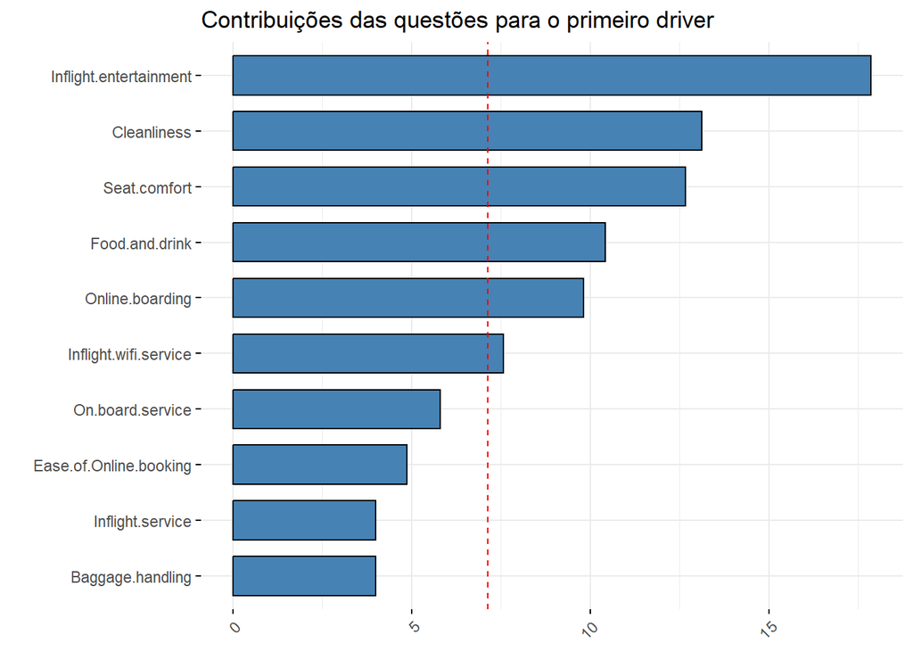

```r
pca %>%
  fviz_contrib(choice = "var", axes = 1, sort.val = "asc", top = 10,
               fill = "steelblue", color = "black") +
  labs(x = "", title = "Contribuições das questões para o primeiro driver") +
  coord_flip()
```

#### 2º Driver: EMBARQUE

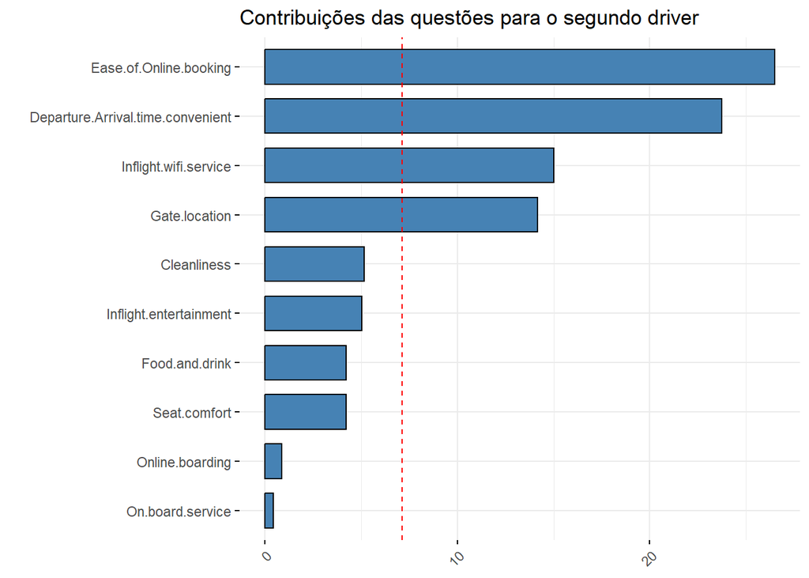

```r
pca %>%
  fviz_contrib(choice = "var", axes = 2, sort.val = "asc", top = 10,
               fill = "steelblue", color = "black") +
  labs(x = "", title = "Contribuições das questões para o segundo driver") +
  coord_flip()
```

#### 3º Driver: ATENDIMENTO

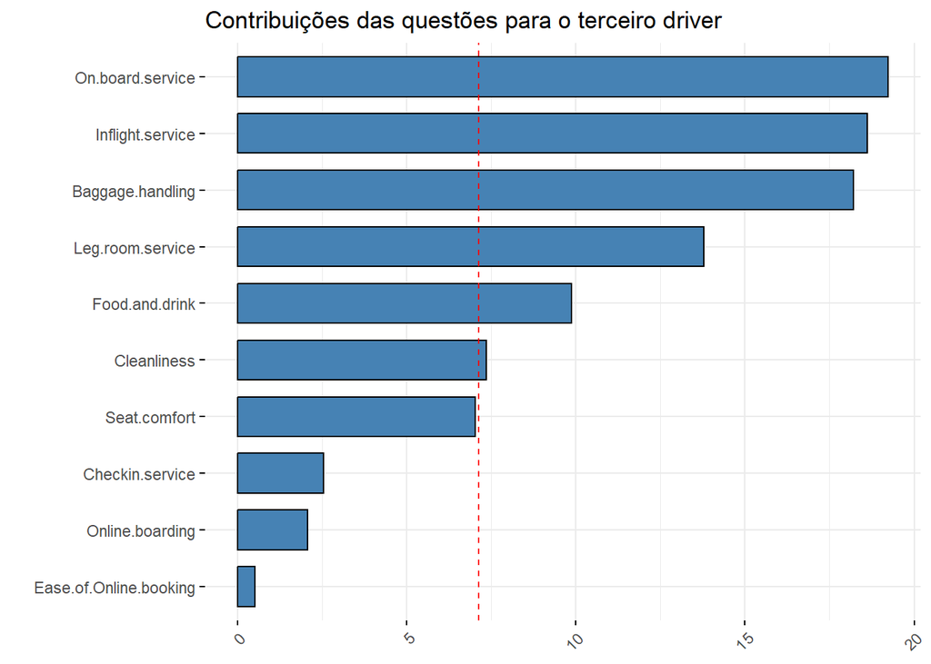

```r
pca %>%
  fviz_contrib(choice = "var", axes = 3, sort.val = "asc", top = 10,
               fill = "steelblue", color = "black") +
  labs(x = "", title = "Contribuições das questões para o terceiro driver") +
  coord_flip()
```

Através do PCA, percebe-se que as características mais valorizadas pelos passageiros são conforto, facilidade no embarque e qualidade do atendimento.

### Clusterização

Para melhor entendimento dos passageiros que frequentam as companhias aéreas, foi feito uma clusterização utilizando **k-means** e **método do joelho**

## Preparação inicial dos dados

A nova base **bd2** contém os valores de *z* para as predições

```r
bd2 <- bdzero

bd2$conforto <- Z[,1]

bd2$embarque <- Z[,2]

bd2$atendimento <- Z[,3]

bd2$satisfaction [bd2$satisfaction == "neutral or dissatisfied"] <- 1
bd2$satisfaction [bd2$satisfaction == "satisfied"] <- 0
bd2$satisfaction <- as.integer(bd2$satisfaction)

bd2$id <- NULL
```

## K-Means

Foi feito o **One-Hot-Encoding** e **Scale** das variáveis antes de aplicar o k-means

```r
#one-hot-encoding

dmy <- dummyVars(" ~ .", data = bd2)
bd3 <- data.frame(predict(dmy, newdata = bd2))

#Scaling
bd3_scaled <- bd3

bd3_scaled[is.na(bd3_scaled)] <- 0

bd3_scaled <- bd3_scaled %>%
  scale()

bd3_scaled <- as.data.frame(bd3_scaled)
```

Para se escolher a quantidade de clusters, utilizou-se o **Método do Joelho** e discussões acerca da natureza do negócio analisado

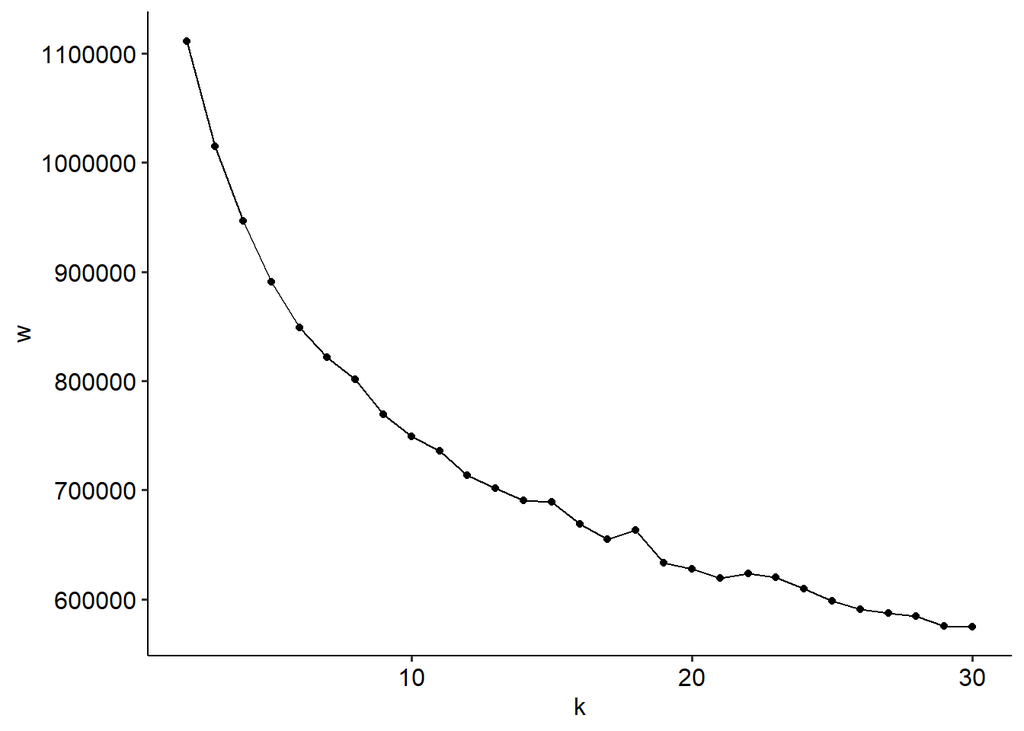

```r
set.seed(123)

tibble(k = 2:30) %>%
  mutate(w = map_dbl(k, ~ kmeans(bd3_scaled, centers = .x)$tot.withinss)) %>%
  ggplot(aes(k, w)) +
  geom_point() +
  geom_line()
```

Segundo o Método do Joelho, 9 clusters seriam uma boa escolha, porém, ao analisar comparativamente a média das variáveis de cada um dos 9 clusters e discutir sobre a natureza do negócio, decidiu-se utilizar somente 5 clusters para apoio no estudo e interpretação do problema apresnetado

## Montagem dos Clusters

```r
set.seed(123)
descricao <- bd3_scaled %>%
    mutate(cluster = factor(kmeans(bd3_scaled, centers = 5)$cluster))

set.seed(123)
descricao9 <- bd3_scaled %>%
    mutate(cluster9 = factor(kmeans(bd3_scaled, centers = 9)$cluster))
```

### Tabela comparativa com as médias de cada variável em cada um dos clusters

```r
bd2$cluster <- descricao[,32]
bd2$cluster <- descricao[,32]

bd4 <- bd2
bd4_9 <- bd2
bd4_9$cluster9 <- descricao9[,32]

bd4[7:20] <- NULL
bd4_9[7:20] <- NULL

bd4[is.na(bd4)] <- 0
bd4_9[is.na(bd4_9)] <- 0

bd4$satisfaction <- as.factor(bd4$satisfaction)
bd4_9$satisfaction <- as.factor(bd4_9$satisfaction)

tabela1 <- bd4 %>%
  group_by(cluster) %>%
  summarise(across(where(is.numeric), mean))



tabela1
```

```
## # A tibble: 5 × 8
##   cluster   Age Flight.Distance Departure.Delay.in.Minu…¹ Arrival.Delay.in.Min…²
##   <fct>   <dbl>           <dbl>                     <dbl>                  <dbl>
## 1 1        44.6           1305.                      15.5                   16.1
## 2 2        30.0            710.                      15.1                   15.5
## 3 3        34.6            873.                      21.8                   22.2
## 4 4        44.1           1773.                      12.2                   12.3
## 5 5        39.0            767.                      12.3                   12.5
## # ℹ abbreviated names: ¹Departure.Delay.in.Minutes, ²Arrival.Delay.in.Minutes
## # ℹ 3 more variables: conforto <dbl>, embarque <dbl>, atendimento <dbl>
```

```r
tabela9 <- bd4_9 %>%
  group_by(cluster9) %>%
  summarise(across(where(is.numeric), mean))


tabela9
```

```
## # A tibble: 9 × 8
##   cluster9   Age Flight.Distance Departure.Delay.in.Min…¹ Arrival.Delay.in.Min…²
##   <fct>    <dbl>           <dbl>                    <dbl>                  <dbl>
## 1 1         38.7           1242.                    37.8                    38.9
## 2 2         30.2            733.                    11.8                    12.0
## 3 3         33.8            780.                    12.5                    12.6
## 4 4         44.1           1795.                    12.1                    12.3
## 5 5         39.3            777.                    12.9                    13.1
## 6 6         44.0           1781.                    11.3                    11.4
## 7 7         48.5           1202.                     9.74                   10.2
## 8 8         43.1           1636.                    11.7                    11.8
## 9 9         29.7            689.                    15.3                    15.8
## # ℹ abbreviated names: ¹Departure.Delay.in.Minutes, ²Arrival.Delay.in.Minutes
## # ℹ 3 more variables: conforto <dbl>, embarque <dbl>, atendimento <dbl>
```

Para finalizar a análise exploratória dos dados, percebeu-se queo cluster 4 contém a maioria dos clientes satisfeitos, sendo o único cluster com mais clientes satisfeitos do que insatisfeitos.

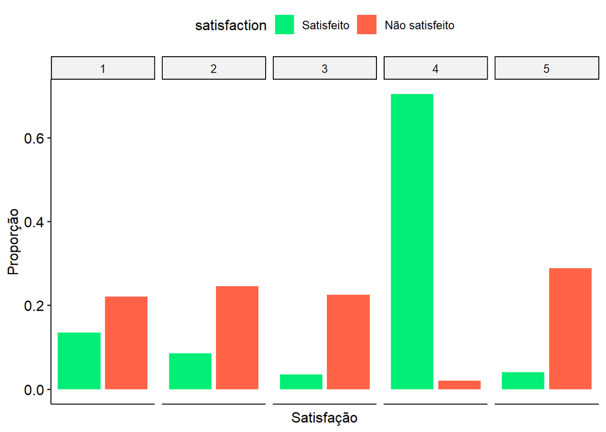

```r
p<- ggplot(bd4) +
  stat_count(mapping = aes(x = satisfaction, y = ..count../tapply(..count.., ..x.. , sum)[..x..],
                          fill=satisfaction),
             position = position_dodge2(preserve = "single")) +
  facet_grid(.~ cluster) + xlab("Satisfação") +ylab("Proporção")

p<-p+ scale_fill_manual(values = c("springgreen2", "tomato1"), labels = c("Satisfeito", "Não satisfeito"))

 p+ theme(
  axis.text.x=element_blank(),
  axis.ticks.x=element_blank()
)
```

## Modelagem

### Regressão Logística e Rede Neural

Os modelos escolhidos para a análise foram a Regressão Logística e a Rede Neural. Decidiu-se utilizar somente as componentes calculadas pelo PCA, as variáveis dummies e a variável resposta nos modelos, com o objetvo de predizer se o passageiro estará satisfeito com o voo.

### Seprando dos dados em treino e teste

Foi escolhida a separção dos dados em 70% treino e 30% teste. Os dados foram normalizados e criou-se as variáveis dummies com o pacote [recipe].

```
## 'data.frame':    29092 obs. of  9 variables:
##  $ Gender        : chr  "Male" "Female" "Male" "Female" ...
##  $ Customer.Type : chr  "Loyal Customer" "Loyal Customer" "Loyal Customer" "disloyal Customer" ...
##  $ Type.of.Travel: chr  "Business travel" "Business travel" "Business travel" "Business travel" ...
##  $ Class         : chr  "Business" "Business" "Business" "Eco" ...
##  $ satisfaction  : Factor w/ 2 levels "0","1": 1 1 1 1 1 1 1 1 1 1 ...
##  $ conforto      : num  1.16 4.72 3.65 -1.43 2.12 ...
##  $ embarque      : num  -0.0812 -0.1417 0.2615 -1.7898 -2.1296 ...
##  $ atendimento   : num  0.964 -0.954 -1.392 -3.563 0.437 ...
##  $ cluster       : Factor w/ 5 levels "1","2","3","4",..: 4 4 4 2 4 4 4 4 4 2 ...
```

### Regressão Logística

```r
fit_glm2 <- logistic_reg() %>%
  set_engine("glm") %>%
  set_mode("classification") %>%
  fit(satisfaction ~ ., treinamento_proc2)

tidy(fit_glm2)
```

```
## # A tibble: 13 × 5
##    term                           estimate std.error statistic   p.value
##    <chr>                             <dbl>     <dbl>     <dbl>     <dbl>
##  1 (Intercept)                      1.40      0.271      5.16  2.43e-  7
##  2 conforto                        -0.922     0.0282   -32.7   1.03e-234
##  3 embarque                        -0.0188    0.0197    -0.951 3.41e-  1
##  4 atendimento                      0.0337    0.0238     1.42  1.56e-  1
##  5 cluster2                        -0.412     0.273     -1.51  1.32e-  1
##  6 cluster3                         0.380     0.0865     4.39  1.11e-  5
##  7 cluster4                        -2.72      0.0838   -32.5   5.68e-232
##  8 cluster5                         1.64      0.0970    16.9   7.59e- 64
##  9 Gender_Male                     -0.0697    0.0373    -1.87  6.14e-  2
## 10 Customer.Type_Loyal.Customer    -1.36      0.267     -5.08  3.73e-  7
## 11 Type.of.Travel_Personal.Travel   0.693     0.0730     9.50  2.13e- 21
## 12 Class_Eco                        0.368     0.0455     8.09  5.98e- 16
## 13 Class_Eco.Plus                   0.521     0.0750     6.95  3.75e- 12
```

```r
fitted2 <- fit_glm2 %>%
  predict(new_data = teste_proc2, type = "prob") %>%
  mutate(observado = teste_proc2$satisfaction,
         modelo = "logistica")
```

### Rede Neural

Para utilizar a rede neural, retirou-se a variável resposta e os clusters do dataset e as dummies foram tranformadas em One-Hot-Encoding

```r
treinamento_proc_net <-  treinamento_proc2 %>% dplyr::select(-c(satisfaction, cluster))
teste_proc_net <- teste_proc2 %>% dplyr::select(-c(satisfaction, cluster))

dmy2 <- dummyVars("~.", data = treinamento_proc_net)
treino_ohe_bd5 <- data.frame(predict(dmy2, newdata = treinamento_proc2))

dmy3 <- dummyVars("~.", data = teste_proc_net)
teste_ohe_bd5 <- data.frame(predict(dmy3, newdata = teste_proc_net))


treino_net <- treino_ohe_bd5 %>% as.matrix()
teste_net <- teste_ohe_bd5 %>% as.matrix()
```

#### Configuração da Rede Neural

Utilizou-se uma rede de três camadas com as funções de ativação [relu] e [softmax].

```r
treino_respost <-to_categorical(treinamento_proc2$satisfaction, num_classes = 2)
teste_respost <- to_categorical(teste_proc2$satisfaction, num_classes = 2)

model <- keras_model_sequential() %>%
  layer_dense(units = 64,
              activation = "relu",
              input_shape = c(ncol(treino_net))) %>%
  layer_dense(units = 64,
              activation = "relu") %>%
  layer_dense(units = ncol(treino_respost),
              activation = "softmax")
```

#### Compile da Rede Neural

A Rede Neural utilizou uma função de otmização [rmsprop], uma função de perda [binary_crossentropy] e a métrica monitorada foi [accuracy]

```r
net <- compile(model, optimizer = "rmsprop",
                      loss = "binary_crossentropy",
                      metrics = "accuracy")


history <- fit(net, treino_net, as.matrix(treino_respost),
               epochs = 10,
               batch_size = 128,
               validation_data = list(teste_net, teste_respost))
```

```
## 228/228 - 1s - loss: 0.3602 - accuracy: 0.8600 - val_loss: 0.2881 - val_accuracy: 0.8847 - 1s/epoch - 6ms/step
## 228/228 - 0s - loss: 0.2897 - accuracy: 0.8851 - val_loss: 0.2708 - val_accuracy: 0.8917 - 430ms/epoch - 2ms/step
## 228/228 - 0s - loss: 0.2790 - accuracy: 0.8883 - val_loss: 0.2700 - val_accuracy: 0.8903 - 420ms/epoch - 2ms/step
## 228/228 - 0s - loss: 0.2750 - accuracy: 0.8884 - val_loss: 0.2616 - val_accuracy: 0.8955 - 436ms/epoch - 2ms/step
## 228/228 - 0s - loss: 0.2717 - accuracy: 0.8913 - val_loss: 0.2594 - val_accuracy: 0.8957 - 463ms/epoch - 2ms/step
## 228/228 - 0s - loss: 0.2696 - accuracy: 0.8923 - val_loss: 0.2616 - val_accuracy: 0.8938 - 409ms/epoch - 2ms/step
## 228/228 - 0s - loss: 0.2675 - accuracy: 0.8926 - val_loss: 0.2585 - val_accuracy: 0.8954 - 490ms/epoch - 2ms/step
## 228/228 - 0s - loss: 0.2663 - accuracy: 0.8929 - val_loss: 0.2607 - val_accuracy: 0.8953 - 433ms/epoch - 2ms/step
## 228/228 - 0s - loss: 0.2654 - accuracy: 0.8928 - val_loss: 0.2553 - val_accuracy: 0.8977 - 492ms/epoch - 2ms/step
## 228/228 - 1s - loss: 0.2640 - accuracy: 0.8940 - val_loss: 0.2533 - val_accuracy: 0.8989 - 547ms/epoch - 2ms/step
```

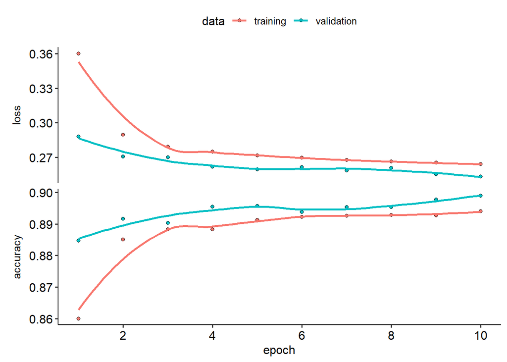

```r
plot(history)
```

### Aplicação da Rede Neural

O modelo foi aplicado na base de testes para se quantificar a performance e comparar com a Regressão Logística

```r
net_pred <- net %>% predict(teste_net) %>% `>`(0.5) %>% k_cast("int32") %>%  k_get_value()
```

```
## 390/390 - 0s - 376ms/epoch - 963us/step
```

```r
rede_resposta <- data.frame(pred=net_pred,
           observado=teste_proc2$satisfaction)

rede_resposta <- rede_resposta %>% rename(.pred_0 =pred.1 , .pred_1 = pred.2 )

fitted3 <-  rede_resposta  %>%
  mutate(modelo = "rede neural") %>% as.tibble()
```

## Avaliação dos Modelos

Como a base de dados é bem balanceada, decidiu-se utilizar a curva ROC como métrica de desempenho dos modelos

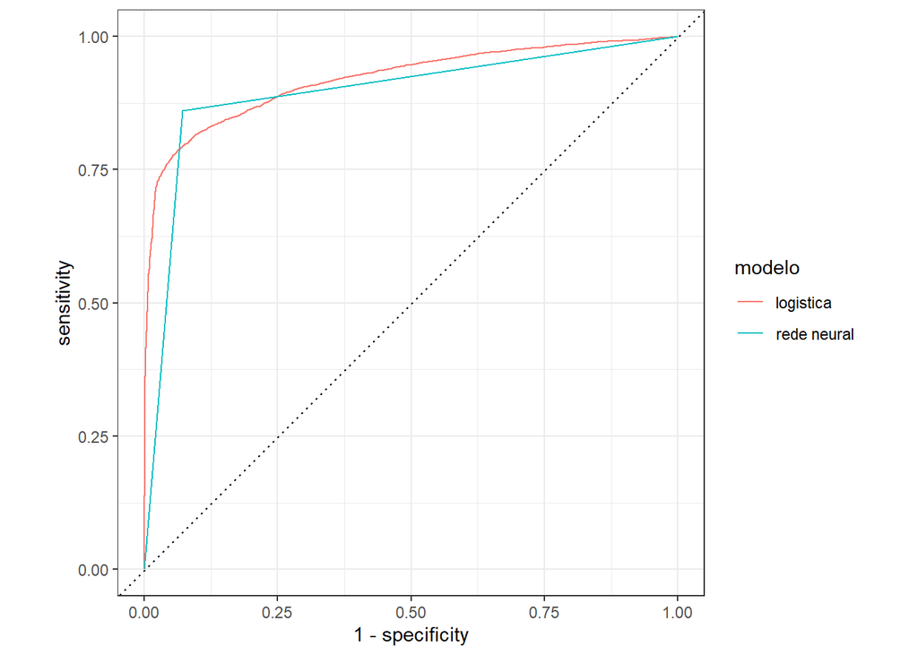

```r
avaliacao <- bind_rows(fitted2, fitted3)

avaliacao %>%
  group_by(modelo) %>%
  roc_curve(observado, .pred_0) %>% autoplot()
```

```r
avaliacao %>%
  group_by(modelo) %>%
  roc_auc(observado, .pred_0)
```

```
## # A tibble: 2 × 4
##   modelo      .metric .estimator .estimate
##   <chr>       <chr>   <chr>          <dbl>
## 1 logistica   roc_auc binary         0.920
## 2 rede neural roc_auc binary         0.894
```

## Conclusão

Opta-se pela regressão logística para predizer a satisfação dos passageiros. A regressão logística, modelo mais simples, performou melhor que a rede neural para predizer a variável resposta. Conforme encontra-se empíricamente e através da consulta à literatura, para problemas mais simples e com poucas variáveis, a regressão logística tende a ter melhor resultado; como aqui foi exposto. A rede neural tende a se sair melhor em problemas mais complexos, como, por exemplo, classificação de imagem; além disso, por ser um modelo mais complexo, não é a melhor escolha para abordar o problema trabalhado aqui neste material.